# SC19022: the Homework of Statistic Computing

## Homework 10

### 11.1 Question:

The natural logarithm and exponential functions are inverses of each other, so that mathematically log(exp $x$) = exp(log $x$) = $x$. Show by example that this property does not hold exactly in computer arithmetic. Does the identity hold with near equality? (See all.equal.)

### Answer:

```r
x <- 0.1
ex1 <- exp(log(x))
ex2 <- log(exp(x))
isTRUE(ex1 == ex2)
```

```
## [1] FALSE
```

```r
isTRUE(all.equal(ex1, ex2))
```

```
## [1] TRUE
```

> This shows that the two expressions are not equal exactly in computer arithmetic, while they are near equal.

### 11.5 Question:

Write a function to solve the equation
$$\begin{aligned} \frac{2 \Gamma\left(\frac{k}{2}\right)}{\sqrt{\pi(k-1)}\Gamma\left(\frac{k-1}{2}\right)} \int_{0}^{c_{k-1}}\left(1+\frac{u^{2}}{k-1}\right)^{-k / 2} \mathrm d u &
\\= \frac{2 \Gamma\left(\frac{k+1}{2}\right)}{\sqrt{\pi k}\Gamma\left(\frac{k}{2}\right)}\int_{0}^{c_{k}}\left(1+\frac{u^{2}}{k}\right)^{-(k+1) / 2} \mathrm d u \end{aligned}$$
for $a$, where
$$c_{k}=\sqrt{\frac{a^{2} k}{k+1-a^{2}}}$$
Compare the solutions with the points $A(k)$ in Exercise 11.4.

### Answer:

recall ex 11.4:

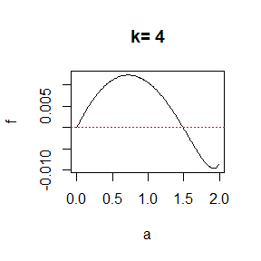

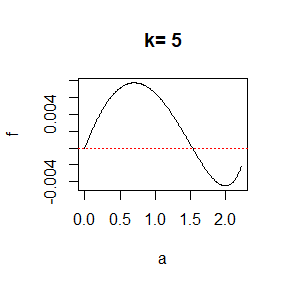

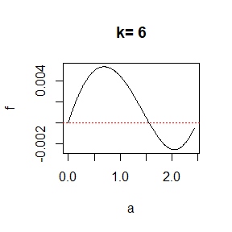

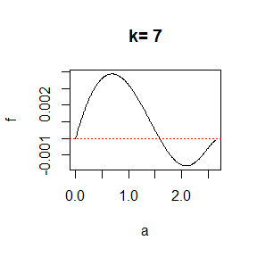

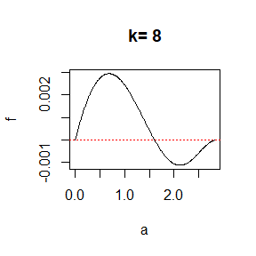

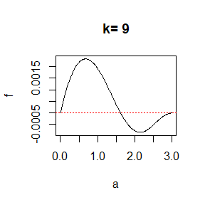

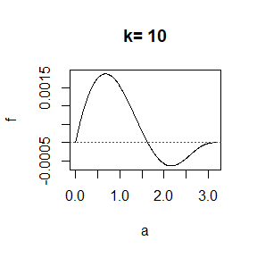

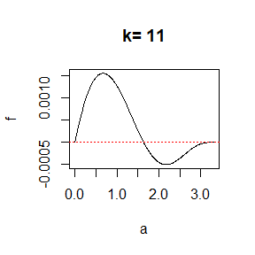

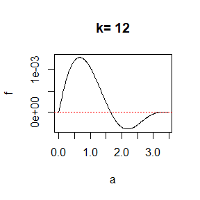

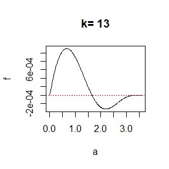

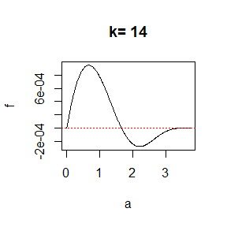

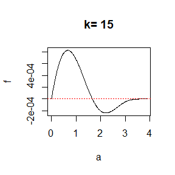

[13 more figures not shown]

```r
b <- c(4:25, 100, 500, 1000) # this is the freedom degree.
m <- matrix(NA, nrow = 25, ncol = 3)

f <- function(a, k) {
  pt(sqrt(a^2*k/(k+1-a^2)), df = k, log.p = TRUE) -
    pt(sqrt(a^2*(k-1)/(k-a^2)), df = k-1, log.p = TRUE)}


for (i in 1:25) {
  k <- b[i]
  xx <- seq(1e-5, sqrt(b[i])-1e-5, .01)
  g <- function(a) f(a, b[i])
  yy <- apply(as.matrix(xx), 1, g)
  plot(xx, yy, type = "l", main = paste("k=",b[i]),
       xlab = "a", ylab = "f")
  abline(h = 0, col = "red",lty=3)
}
```

By these pictures, there is only one intersection point in $(0,2)$. so we can use ‘uniroot’ straightly to find the intersection point in $(0,2)$ interval. when $a >2$ , it also shows that the two value of function is very close, but we guess they are just very near , other than equal. so we abandon the solution in $(2, \sqrt k )$.

then , give the solution of 11.5

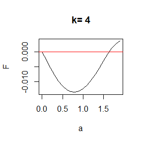

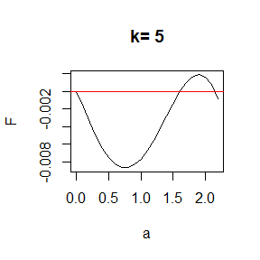

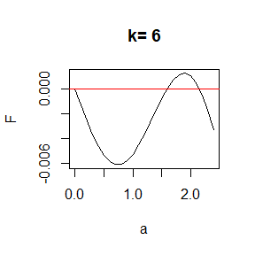

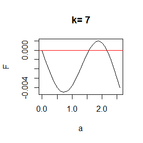

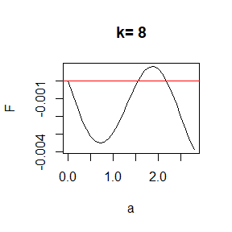

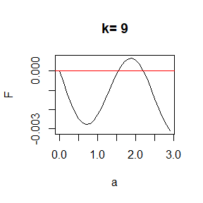

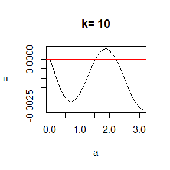

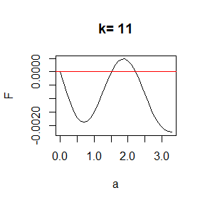

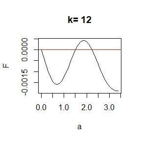

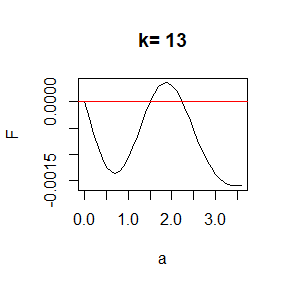

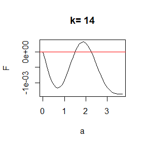

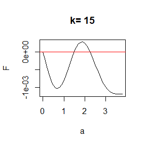

[13 more figures not shown]

```r
ak1 <- function(k) {
 # to computer the intersection point in exercise 11.4
  res <- uniroot(f, c(1e-5, 2), k=k)
  res$root
}

m[ ,1] <- apply(as.matrix(b), 1, ak1)



F <- function(a, k) {
  # this function is to calculate s(a, k) - s(a, k+1)
  ck <- function(a, k) sqrt( a^2*k/(k+1-a^2))
  g <- function(u) (1+u^2/(k-1))^(-k/2)
  int <- function(a, k) integrate(g, lower = 0, upper = ck(a, k))

  s <- function(a, k) {
    exp( log(2/sqrt(pi*(k-1))) + lgamma(k/2)
         - lgamma((k-1)/2) +log(int(a,k)$value))
  }

  s(a, k) - s(a, k+1)
}


for (i in 1:25) {
  k <- b[i]
  xx <- seq(1e-5, sqrt(b[i])-1e-5, 0.1)
  G <- function(a) F(a, b[i])
  yy <- apply(as.matrix(xx), 1, G)
   plot(xx, yy, type = "l", main = paste("k=",b[i]),
       xlab = "a", ylab = "F")
  abline(h = 0, col = "red")
}
```

Here, there are two intersection points in $(0,\sqrt{k})$ obviously, since the curve shows the trend, we can separete the $(0,\sqrt{k})$ into in $(0,2)$ , $(2,\sqrt{k})$.

```r
ak2 <- function(k) {
  # to computer the intersection point in (0,2)
  res <- uniroot(F, c(1e-5, 2), k=k)
  res$root
}
m[ ,2] <- apply(as.matrix(b), 1, ak2)

ak3 <- function(k) {
  # to computer the intersection point
  res <- uniroot(F, c(1.8, 2.5), k=k)
  res$root
}

m[3:25,3] <- apply(as.matrix(b[3:25]), 1, ak3)
m[2,3] <- uniroot(F, c(1.8, sqrt(5)), k=5)$root
colnames(m) <- c("intersection point in 11.4",
                 "1st intersection point in 11.5",
                 "2nd intersection point in 11.5")

knitr::kable(m)
```

| intersection point in 11.4 | 1st intersection point in 11.5 | 2nd intersection point in 11.5 |
| --- | --- | --- |
| 1.492105 | 1.642347 | NA |
| 1.533559 | 1.614479 | 2.152348 |
| 1.562751 | 1.587570 | 2.155957 |
| 1.584447 | 1.565494 | 2.168024 |
| 1.601152 | 1.547934 | 2.182512 |
| 1.614499 | 1.533936 | 2.197098 |
| 1.625377 | 1.522609 | 2.210905 |
| 1.634413 | 1.513300 | 2.223653 |
| 1.642031 | 1.505540 | 2.235301 |
| 1.648547 | 1.498986 | 2.245907 |
| 1.654183 | 1.493377 | 2.255560 |
| 1.659106 | 1.488527 | 2.264356 |
| 1.663444 | 1.484232 | 2.272391 |
| 1.667295 | 1.480505 | 2.279747 |
| 1.670736 | 1.477201 | 2.286501 |
| 1.673831 | 1.474252 | 2.292710 |
| 1.676628 | 1.471604 | 2.298453 |
| 1.679169 | 1.469214 | 2.303768 |
| 1.681487 | 1.467045 | 2.308700 |
| 1.683611 | 1.465069 | 2.313288 |
| 1.685563 | 1.463262 | 2.317566 |
| 1.687364 | 1.461601 | 2.321563 |
| 1.720629 | 1.432279 | 2.404658 |
| 1.729717 | 1.424660 | 2.430820 |
| 1.730869 | 1.423714 | 2.434226 |

### EXERCISE: A-B-O blood type problem

Let the three alleles be $A, B,$ and $O$ with allele frequencies $p,$ $q,$ and $r .$ The 6 genotype frequencies under HWE and complete counts are as follows.
$$\begin{array}{|c|c|c|c|c|c|c|}\hline \text { Genotype } & {A A} & {B B} & {O O} & {A O} & {B O} & {A B} & {S u m} \\ \hline \text { Frequency } & {p^{2}} & {q^{2}} & {r^{2}} & {2 p r} & {2 q r} & {2 p q} & {1} \\ \hline \text { Count } & {n A A} & {n B B} & {n O O} & {n A O} & {n B O} & {n A B} & {n} \\ \hline\end{array}$$
Observed data:

$n_{O O}=41(\text {O - type }),$

$n_{A B}=70(\text {AB - type })$

question1: Use EM algorithm to solve MLE of $p$ and $q$ (consider missing data $n_{AA}$ and $n_{BB}$).

question2: Show that the log-maximum likelihood values in M-steps are increasing via line plot.

### Answer:

For this problem, we can give the expectation of log likelihood function:
$$\begin{aligned} E \log f\left(y | \lambda^{(t)}\right) &=n_{A A}^{(t)} \cdot \log p^{2}+n_{B B}^{(t)} \cdot \log q^{2}+n_{OO}^{(t)} \cdot \log r^{2} \\ &+n_{A B}^{(t)} \cdot \log (2 p q)+n_{A O}^{(t)} \cdot \log (2 p r)+n_{B O}^{(t)} \cdot \log (2 q r)
\\ &+ E \cdot log \frac{n !}{n_{A A}^{(t)}! n_{A B}^{(t)} ! n_{B B}^{(t)} ! n_{OO}^{(t)} ! n_{AO}^{(t)}! n_{BO}^{(t)}!}
\end{aligned}$$
here, in the $t$ step:
$$\begin{array}{l}{n_{A A}^{(t)}=\left(n_{A} \cdot\right) \frac{\left(p^{(t)}\right)^{2}}{\left(p^{(t)}\right)^{2}+2 p^{(t)} \cdot r^{(t)}}}
\\ {n_{B B}^{(t)}=\left(n_{B} \cdot\right) \frac{\left(q^{(t)}\right)^{2}}{\left(q^{(t)}\right)^{2}+2 q^{(t)} \cdot r^{(t)}}}
\\ {n_{A O}^{(t)}=\left(n_{A} \cdot\right) \frac{2 p^{(t)} \cdot r^{(t)}}{\left(p^{(t)}\right)^{2}+2 p^{(t)} r^{(t)}}}
\\ {n_{B O}^{(t)}=\left(n_{B}\cdot\right) \frac{2 q^{(t)} \cdot r^{(t)}}{\left(q^{(t)}\right)^{2}+2 q^{(t)} \cdot r^{(t)}}}\end{array}$$
and by maximum the log likelihood , we can get the $p, q, r$ in $t + 1$step.
$$\begin{array}{l}{p^{(t+1)}=\frac{2 n_{A A}^{(t)}+n_{A B}^{(t)}+n_{A O}^{(t)}}{2 n}} \\ {q^{(t+1)}=\frac{2 n_{B B}^{(t)}+n_{A B}^{(t)}+n_{B O}^{(t)}}{2 n}} \\ {r^{(t+1)}=\frac{2 n_{OO}^{(t)}+n_{A O}^{(t)}+n_{BO}^{(t)}}{2 n}}\end{array}$$

```r
N <-100
tol <- .Machine$double.eps^0.5   # the digit of converge
na <- 24
nb <- 28
noo <- 41
nab <- 70
n <- sum(na, nb, noo, nab)

p <- q <- r <- Elogl <- rep(0, N)
p[1] <- q[1] <- 1/3              # the original p, q ,r
k <- 0
for (i in 2:N) {
  p.old <- p[i-1]
  q.old <- q[i-1]
  r.old <- 1-p.old-q.old

  naa <- na * p.old^2 / (p.old^2 + 2*p.old*r.old)
  nbb <- nb * q.old^2 / (q.old^2 + 2*q.old*r.old)
  nao <- na * 2 * p.old * r.old / (p.old^2 + 2*p.old*r.old)
  nbo <- nb * 2 * q.old * r.old / (q.old^2 + 2*q.old*r.old)

  p[i] <- sum(2*naa, nab, nao) / (2*n)
  q[i] <- sum(2*nbb, nab, nbo) / (2*n)
  r[i] <- sum(2*noo, nao, nbo) / (2*n)

  if (sum( abs(p[i]-p.old)/p.old < tol))
      break

  Elogl[i-1] <- naa*2*log(p[i]) + nbb*2*log(q[i]) +
    noo*2*log(r[i]) + nab*log(2*p[i]*q[i]) +
    nao*log(2*p[i]*r[i]) +
    nbo*log(2*q[i]*r[i])
  prob.hat <- c(p[i], q[i], r[i])
  k <- k + 1
}

print(round(c(p.hat=prob.hat[1], q.hat=prob.hat[2]),3))
```

```
## p.hat q.hat
## 0.310 0.327
```

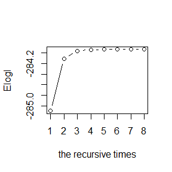

```r
plot(1:k, Elogl[1:k], type = "b",
     xlab = "the recursive times", ylab = "Elogl")
```

## Homework 11

### 11.1.3 Question:

Use both for loops and lapply() to fit linear models to the mtcars using the formulas stored in this list:

formulas <- list(

mpg ~ disp,

mpg ~ I(1 / disp),

mpg ~ disp + wt,

mpg ~ I(1 / disp) + wt

)

### Answer:

```r
disp <- mtcars$disp
mpg <- mtcars$mpg
wt <- mtcars$wt


formulas <- list(
  model1 = mpg ~ disp,
  model2 = mpg ~ I(1 / disp),
  model3 = mpg ~ disp + wt,
  model4 = mpg ~ I(1 / disp) + wt
  )

# by using the lapply function.
lapply(formulas, function(x) lm(x)$coefficients)
```

```
## $model1
## (Intercept)        disp
## 29.59985476 -0.04121512
##
## $model2
## (Intercept)   I(1/disp)
##    10.75202  1557.67393
##
## $model3
## (Intercept)        disp          wt
## 34.96055404 -0.01772474 -3.35082533
##
## $model4
## (Intercept)   I(1/disp)          wt
##   19.024206 1142.559975   -1.797649
```

```r
# by using the for loop.
# we creat a list to save the results firstly.

forloops <- coefficient <- list(model1="1", model2="2",
                            model3="3", model4="4")
for (i in 1:4) {
  forloops[[i]] <- lm(formulas[[i]])
  coefficient[[i]] <- forloops[[i]]$coefficients
}
coefficient
```

```
## $model1
## (Intercept)        disp
## 29.59985476 -0.04121512
##
## $model2
## (Intercept)   I(1/disp)
##    10.75202  1557.67393
##
## $model3
## (Intercept)        disp          wt
## 34.96055404 -0.01772474 -3.35082533
##
## $model4
## (Intercept)   I(1/disp)          wt
##   19.024206 1142.559975   -1.797649
```

### 11.1.4 Question:

Fit the model mpg ~ disp to each of the bootstrap replicates of mtcars in the list below by using a for loop and lapply(). Can you do it without an anonymous function?

bootstraps <- lapply(1:10, function(i) {

rows <- sample(1:nrow(mtcars), rep = TRUE)

mtcars[rows, ]

})

### Answer:

```r
bootstraps <- lapply(1:10, function(i) {
  rows <- sample(1:nrow(mtcars), rep = TRUE)
  mtcars[rows, ]
})


# by using lapply.
temp <- lapply(bootstraps, function(x) lm(x$mpg ~ x$disp)$coefficients)
m1 <- vapply(temp, as.numeric, matrix(0, nrow = 2))
colnames(m1) <- "fit"; rownames(m1) <- c("intercept", "slope")
knitr::kable(round(m1, 4))
```

|  | fit.1 | fit.2 | fit.3 | fit.4 | fit.5 | fit.6 | fit.7 | fit.8 | fit.9 | fit.10 |
| --- | --- | --- | --- | --- | --- | --- | --- | --- | --- | --- |
| intercept | 27.5897 | 30.2285 | 30.4773 | 28.1560 | 28.3408 | 27.6652 | 29.0273 | 28.7769 | 29.7944 | 25.2554 |
| slope | -0.0334 | -0.0430 | -0.0434 | -0.0361 | -0.0376 | -0.0352 | -0.0413 | -0.0369 | -0.0421 | -0.0287 |

```r
# by using a for loop.
forloop <- coefficient2 <- list(fit1="1", fit2="2", fit3="3",
                                fit4="4", fit5="5",fit6="6",
                                fit7="7",fit8="8",fit9="9", fit10="10")
for (i in 1:10) {
  x <- bootstraps[[i]]
  forloop[[i]] <- lm(x$mpg ~ x$disp)
  coefficient2[[i]] <- forloop[[i]]$coefficients
}
temp <- coefficient2
m2 <- vapply(temp, as.numeric, matrix(0, nrow = 2))
colnames(m2) <- "model"; rownames(m2) <- c("intercept", "slope")
knitr::kable(round(m2, 4))
```

|  | model.fit1 | model.fit2 | model.fit3 | model.fit4 | model.fit5 | model.fit6 | model.fit7 | model.fit8 | model.fit9 | model.fit10 |
| --- | --- | --- | --- | --- | --- | --- | --- | --- | --- | --- |
| intercept | 27.5897 | 30.2285 | 30.4773 | 28.1560 | 28.3408 | 27.6652 | 29.0273 | 28.7769 | 29.7944 | 25.2554 |
| slope | -0.0334 | -0.0430 | -0.0434 | -0.0361 | -0.0376 | -0.0352 | -0.0413 | -0.0369 | -0.0421 | -0.0287 |

```r
# without using an anonymous function.
fitfunc <- function(n){
  resmodel <- rescoefficient <- forloop
  for (i in 1:n) {
    rows <- sample(1:nrow(mtcars), rep = TRUE)
    data <- mtcars[rows, ]
    resmodel[[i]] <- lm(data$mpg ~ data$disp)
    rescoefficient[[i]] <- resmodel[[i]]$coefficients
  }
  list(model = resmodel, coefficient = rescoefficient)
}

res <- fitfunc(10)
temp <- res$coefficient
m3 <- vapply(temp, as.numeric, matrix(0, nrow = 2))
colnames(m3) <- "model"; rownames(m3) <- c("intercept", "slope")
knitr::kable(round(m3, 4))
```

|  | model.fit1 | model.fit2 | model.fit3 | model.fit4 | model.fit5 | model.fit6 | model.fit7 | model.fit8 | model.fit9 | model.fit10 |
| --- | --- | --- | --- | --- | --- | --- | --- | --- | --- | --- |
| intercept | 28.5459 | 31.3896 | 30.3376 | 27.2274 | 30.7785 | 29.5807 | 29.0603 | 28.1053 | 31.3753 | 31.5807 |
| slope | -0.0396 | -0.0462 | -0.0463 | -0.0333 | -0.0449 | -0.0391 | -0.0377 | -0.0350 | -0.0459 | -0.0506 |

### 11.1.5 Question:

For each model in the previous two exercises, extract R2 using the function below. rsq <- function(mod) summary(mod)$r.squared

### Answer:

```r
## for exercise 11.1.3
rsq <- function(mod) summary(mod)$r.squared
r1 <- unlist(lapply(forloops, rsq))
knitr::kable(round(t(r1), 4))
```

| model1 | model2 | model3 | model4 |
| --- | --- | --- | --- |
| 0.7183 | 0.8597 | 0.7809 | 0.8838 |

```r
## for exercise 11.1.4 with using anonymous function.
r2 <- unlist(lapply(forloop,rsq))
knitr::kable(round(t(r2), 4))
```

| fit1 | fit2 | fit3 | fit4 | fit5 | fit6 | fit7 | fit8 | fit9 | fit10 |
| --- | --- | --- | --- | --- | --- | --- | --- | --- | --- |
| 0.6934 | 0.7682 | 0.7232 | 0.5836 | 0.6691 | 0.5931 | 0.7969 | 0.6701 | 0.7381 | 0.6873 |

```r
## for exercise 11.1.4 without anonymous function.
r3 <- unlist(lapply(res$model, rsq))
knitr::kable(round(t(r3), 4))
```

| fit1 | fit2 | fit3 | fit4 | fit5 | fit6 | fit7 | fit8 | fit9 | fit10 |
| --- | --- | --- | --- | --- | --- | --- | --- | --- | --- |
| 0.6552 | 0.7308 | 0.7603 | 0.6272 | 0.7598 | 0.637 | 0.6994 | 0.6283 | 0.7814 | 0.7474 |

### 11.2.3 Question:

The following code simulates the performance of a t-test for non-normal data. Use sapply() and an anonymous function to extract the p-value from every trial.

trials <- replicate(

100,

t.test(rpois(10, 10), rpois(7, 10)),

simplify = FALSE

)

Extra challenge: get rid of the anonymous function by using [[ directly.

### Answer:

```r
set.seed(1)
trials <- replicate(
  100,
  t.test(rpois(10, 10), rpois(7, 10)),
  simplify = FALSE
)

# by using sapply and anonymous function.
sapply(trials, function(x) x$p.value)
```

```
##   [1] 0.125949930 0.800930340 0.952855296 0.452959855 0.483083494
##   [6] 0.320611150 0.706780317 0.063119508 0.621092522 0.162276154
##  [11] 0.820427933 0.053095862 0.914712292 0.792200487 0.390189150
##  [16] 0.538640844 0.143988430 0.788393427 0.672267752 0.216269737
##  [21] 0.534646674 0.809214595 0.960266963 0.569466705 0.632178255
##  [26] 0.582700745 0.254983356 0.282179271 0.005098396 0.162075913
##  [31] 0.877783340 0.654074362 0.169752059 0.754440969 0.764179721
##  [36] 0.026793925 0.114713268 0.028496672 0.598991648 0.885239097
##  [41] 0.719211331 0.409696973 0.847167535 0.764438221 0.418863595
##  [46] 0.519132187 0.463910875 0.286785195 0.875030871 0.241068098
##  [51] 0.838739962 0.348638336 0.622633185 0.232606824 0.398974335
##  [56] 0.970218660 0.860375193 0.909101881 0.851096482 0.523397015
##  [61] 0.746860279 0.764894312 0.025411594 0.019036587 0.397989350
##  [66] 0.714919878 0.631471636 0.110724341 0.927143289 0.041990454
##  [71] 0.208117904 0.607178718 0.906974079 0.554576397 0.194404278
##  [76] 0.771678543 0.396686801 0.803958799 0.768941702 0.994186553
##  [81] 0.194123673 0.316046848 0.415575715 0.619270683 0.295629509
##  [86] 0.942948679 0.607585865 0.718018866 0.761453123 0.120281420
##  [91] 0.577128336 0.019315507 0.483007741 0.108496205 0.469918314
##  [96] 0.011282410 0.231024499 0.955230239 0.964944823 0.281065452
```

```r
# by using sapply and '[[' directly.
sapply(trials, '[[', 3)
```

```
##   [1] 0.125949930 0.800930340 0.952855296 0.452959855 0.483083494
##   [6] 0.320611150 0.706780317 0.063119508 0.621092522 0.162276154
##  [11] 0.820427933 0.053095862 0.914712292 0.792200487 0.390189150
##  [16] 0.538640844 0.143988430 0.788393427 0.672267752 0.216269737
##  [21] 0.534646674 0.809214595 0.960266963 0.569466705 0.632178255
##  [26] 0.582700745 0.254983356 0.282179271 0.005098396 0.162075913
##  [31] 0.877783340 0.654074362 0.169752059 0.754440969 0.764179721
##  [36] 0.026793925 0.114713268 0.028496672 0.598991648 0.885239097
##  [41] 0.719211331 0.409696973 0.847167535 0.764438221 0.418863595
##  [46] 0.519132187 0.463910875 0.286785195 0.875030871 0.241068098
##  [51] 0.838739962 0.348638336 0.622633185 0.232606824 0.398974335
##  [56] 0.970218660 0.860375193 0.909101881 0.851096482 0.523397015
##  [61] 0.746860279 0.764894312 0.025411594 0.019036587 0.397989350
##  [66] 0.714919878 0.631471636 0.110724341 0.927143289 0.041990454
##  [71] 0.208117904 0.607178718 0.906974079 0.554576397 0.194404278
##  [76] 0.771678543 0.396686801 0.803958799 0.768941702 0.994186553
##  [81] 0.194123673 0.316046848 0.415575715 0.619270683 0.295629509
##  [86] 0.942948679 0.607585865 0.718018866 0.761453123 0.120281420
##  [91] 0.577128336 0.019315507 0.483007741 0.108496205 0.469918314
##  [96] 0.011282410 0.231024499 0.955230239 0.964944823 0.281065452
```

### 11.2.7 Question:

Implement mcsapply(), a multicore version of sapply(). Can you implement mcvapply(), a parallel version of vapply()? Why or why not?

### Answer:

```r
## recall the additional homework in 11/22, the solution is really
## taking much time. For this reason, we attempt to write a code
## with parallel computing by parSapply function. We suppose five
## sampling size (5,10,15,20,25) for the model Y = X/4+e, computing
## the p-value by sapply and parSapply respectively, and compare
## with the results, by the way, it also contains the consuming
## time for the consequence.


library(parallel)
library(MASS)
library(energy)

p.value <- function(n) {
  mu <- rep(0, 2)
  sigma <- diag(2)
  alpha <- .1

  pv1 <- replicate(1000, expr = {
    x <- MASS::mvrnorm(n, mu, sigma)
    e <- MASS::mvrnorm(n, mu, sigma)
    y <- x / 4 + e
    energy::dcov.test(x, y, R = 199)$p.value})

  p <- mean( pv1 < alpha )
  return(p)
}

n <- seq(5, 25, 5)
sapply(n, p.value)
```

```
## [1] 0.115 0.171 0.205 0.262 0.300
```

```r
cl <- makeCluster(4)
parSapply(cl, n, p.value)
```

```
## [1] 0.109 0.170 0.220 0.260 0.296
```

```r
system.time(sapply(n, p.value))
```

```
## 用户 系统 流逝
## 3.24 0.00 3.33
```

```r
system.time(parSapply(cl, n, p.value))
```

```
## 用户 系统 流逝
## 0.00 0.00 1.58
```

```r
stopCluster(cl)
```

As for the parallel verison of vapply. I think it is infeasible. If we use the mcvapply, you must assign the your output type in mcvapply. However, since the parallel computing operates by dividing into different cores. The length of vector in single core is possiblely different to the length of combing results which you assign, it will generate an error.

## Homework 12

### Question:

You have already written an R function for Exercise 9.4 (page277, Statistical Computing with R). Rewrite an Rcpp function for the same task.

1.Compare the generated random numbers by the two functions using qqplot.

2.Campare the computation time of the two functions with microbenchmark.

3.Comments your results.

### Answer:

```r
library(Rcpp)
library(microbenchmark)
```

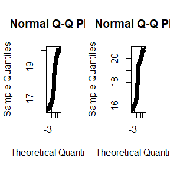

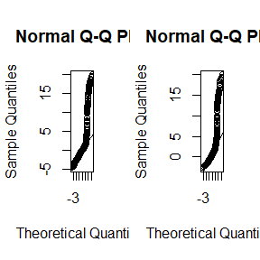

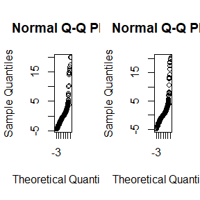

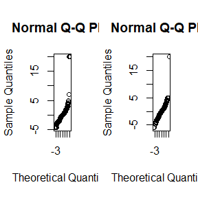

```r
set.seed(1)

# df is the density function
# of standard laplace distribution.
df <- function(x) {
  f <- exp(-abs(x)) / 2
  return(f)
}

rwmR<- function(sigma, x0, N) {
  x <- numeric(N)
  x[1] <- x0
  u <- runif(N)
  for (i in 2:N) {
    y <- rnorm(1, x[i-1], sigma)
    if (u[i] <= (df(y) / df(x[i-1])))
      x[i] <- y
    else {
      x[i] <- x[i-1]
    }
  }
  return(x)
}


cppFunction(
'NumericVector rwmC(double sigma, double x0, int N){
NumericVector x(N);
x[0] = x0;
NumericVector u = as<NumericVector>(runif(N));

for(int i = 1; i < N; i++){
double y = as<double>(rnorm(1, x[i-1], sigma));
if (u[i] <= (exp(-abs(y))/2) / (exp(-abs(x[i-1])) / 2)){
x[i] = y;
}else{
x[i] = x[i-1];
}
}
return(x);
}')


N <- 2000
x0 <- 20
sigma <- c(.05, .5, 2, 16)

rwmR1 <- rwmR(sigma[1], x0, N)
rwmR2 <- rwmR(sigma[2], x0, N)
rwmR3 <- rwmR(sigma[3], x0, N)
rwmR4 <- rwmR(sigma[4], x0, N)

rwmC1 <- rwmC(sigma[1], x0, N)
rwmC2 <- rwmC(sigma[2], x0, N)
rwmC3 <- rwmC(sigma[3], x0, N)
rwmC4 <- rwmC(sigma[4], x0, N)

rwmR <- cbind(rwmR1, rwmR2, rwmR3,  rwmR4)
rwmC <- cbind(rwmC1, rwmC2, rwmC3,  rwmC4)


for (j in 1:4) {
  par(mfrow=c(1,2))
  qqnorm(rwmR[ ,j])
  qqline(rwmR[ ,j])
  qqnorm(rwmC[ ,j])
  qqline(rwmC[ ,j])
}
```

```r
dir <- 'C:/'
source(paste0(dir, 'rwmR.R'))
sourceCpp(paste0(dir, 'rwmC.cpp'))
microbenchmark(rwmR(2, x0, N), rwmC(2, x0, N))
```

```
## Unit: microseconds
##            expr    min      lq     mean median     uq     max neval
##  rwmR(2, x0, N) 8079.6 8354.75 9681.328 8694.1 8793.3 26479.3   100
##  rwmC(2, x0, N)  435.4  473.00  496.806  481.7  489.3  2040.9   100
```

By the QQ-plot, we can see the computing results are nearly same between rwmC and rwmR. But considering the computeing times, rwmC is better than rwmR obviously.